# Breast Cancer Screening Practices Among Women in Jordan

Evidence from the 2017–2018 Jordan Demographic and Health Survey

Rasha Ahmad Al-Qtaishat

July 21, 2026

# 1 Introduction

Breast cancer is an important public-health concern, and early detection can improve the likelihood of timely diagnosis and treatment. Screening-related behaviors, however, are not equally distributed across populations. Age, educational attainment, household economic status, and place of residence may influence women’s awareness of breast cancer, their access to preventive services, and their willingness or ability to seek examination. Understanding these patterns can help identify population groups that may benefit from more focused health education and easier access to screening services.

This report uses the women’s individual recode file from the **Jordan Population and Family Health Survey 2017–2018**, which is part of the Demographic and Health Surveys program. The dataset contains interviews with 14,689 ever-married women aged 15–49 years. The analysis focuses on three indicators: breast self-examination, receiving a breast examination during the previous 12 months, and ever having a mammogram. It also examines how these indicators vary across selected sociodemographic groups. The analysis is descriptive and unweighted, consistent with the methods covered in the bootcamp; therefore, small differences from official weighted DHS estimates are expected.

# 2 Aim

The aim of this report is to describe breast cancer screening practices among women in Jordan and explore variation by age, education, residence, and household wealth.

# 3 Data Preparation and Methods

The raw Stata file was imported with `haven::read_dta()`. Only variables required for the report were selected. DHS-labelled variables were converted to readable categories, variables were renamed, and unclear or missing screening responses were set to missing where appropriate. The workflow demonstrates the use of `select()`, `filter()`, `mutate()`, `case_when()`, `group_by()`, and `summarise()`.

# 4 Findings

## 4.1 Overall Screening Practices

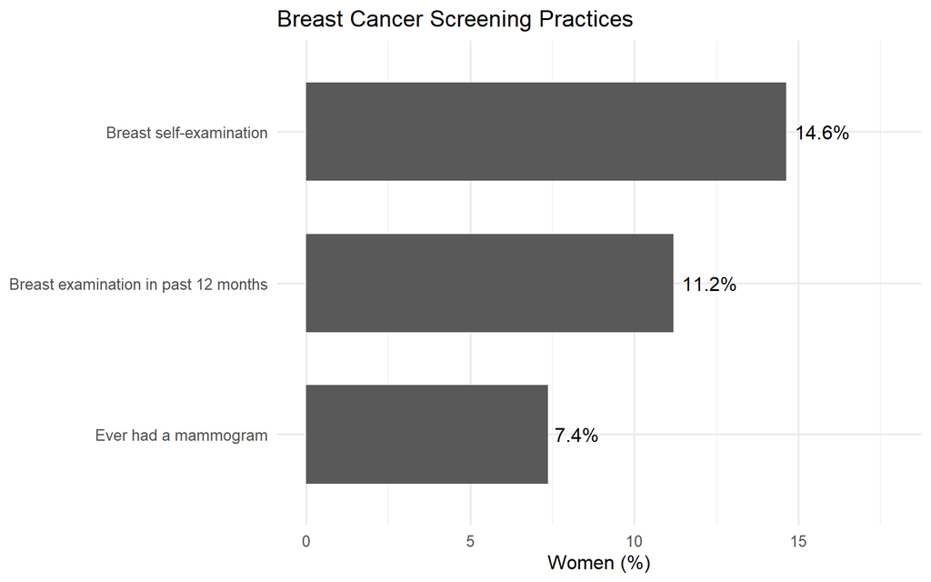

Figure 1. Percentage of surveyed women reporting each breast cancer screening practice.

Breast self-examination was the most commonly reported practice, although it was still reported by only about 14.6% of women. Approximately 11.2% had received a breast examination during the previous year, while 7.4% had ever had a mammogram. These findings suggest that formal screening was less common than self-examination and that preventive screening remained limited in this population.

## 4.2 Mammography by Age Group

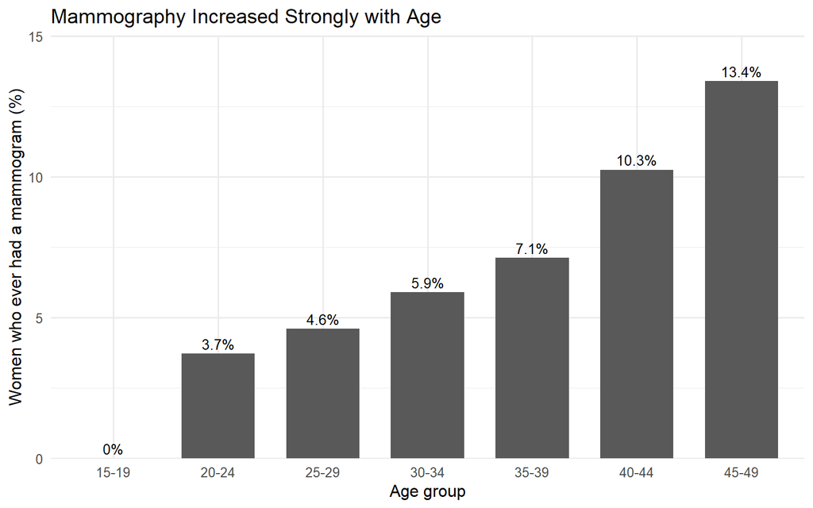

Figure 2. Percentage of women who had ever received a mammogram, by five-year age group.

Mammography use increased markedly with age. The youngest age groups reported very low use, while the highest percentages appeared among women aged 40–49. This pattern is clinically understandable because routine mammography is generally more relevant to older women. Nevertheless, the levels among older women were still modest, indicating that opportunities may exist to improve awareness, referral, and access among women in the age groups most likely to benefit.

## 4.3 Recent Breast Examination by Education

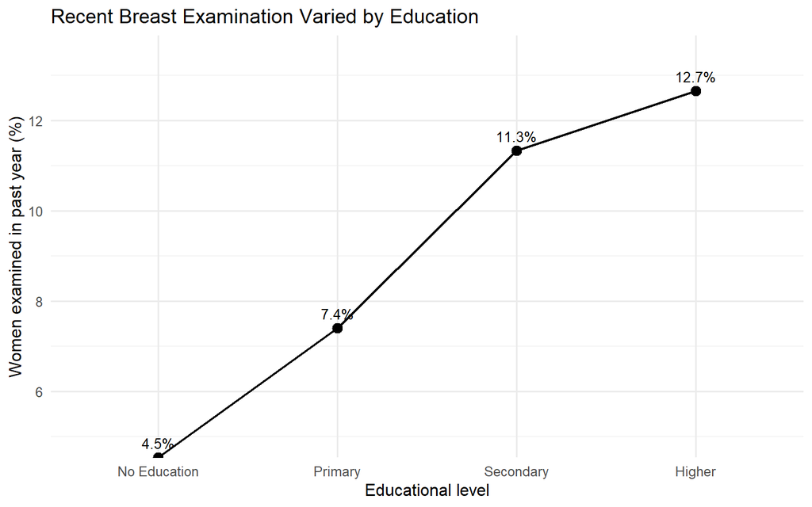

Figure 3. Percentage receiving a breast examination in the previous 12 months, by educational level.

Women with higher education reported breast examination more frequently than women with lower levels of education. Education may increase exposure to health information, confidence in navigating health services, and understanding of preventive care. The pattern should not be interpreted as proof that education directly causes screening behavior, but it identifies an important inequality that health communication programs should consider.

## 4.4 Reasons for Not Having a Mammogram

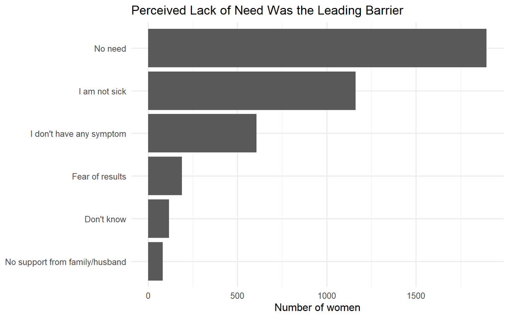

Figure 4. Six most frequently recorded reasons for not having a mammogram.

The most frequent reasons reflected a perceived lack of need: many women reported that they were not sick, had no symptoms, or did not believe a mammogram was necessary. This is an important public-health finding because screening is intended for people who may not have symptoms. Fear of results, lack of family support, distance, and cost were less frequently recorded but remain meaningful barriers for some women.

## 4.5 Display Table: Mammography by Residence and Wealth

Ever Having a Mammogram by Wealth and Residence (unweighted percentages)

| Wealth category | women | Rural | Urban |
| --- | --- | --- | --- |
| Middle | 742 | 8.2 | NA |
| Poorer | 1246 | 5.5 | NA |
| Poorest | 753 | 4.2 | NA |
| Richer | 174 | 11.5 | NA |
| Richest | 21 | 23.8 | NA |
| Middle | 2341 | NA | 7.6 |
| Poorer | 2412 | NA | 5.6 |
| Poorest | 3552 | NA | 4.7 |
| Richer | 2082 | NA | 10.8 |
| Richest | 1336 | NA | 14.2 |

The table permits comparison of economic gradients within urban and rural settings. Mammography was generally more common among women from wealthier households. Residence-based differences should be interpreted carefully because the rural sample is smaller and screening access may vary by region as well as by urban–rural classification.

# 5 Conclusion

Breast cancer screening practices among ever-married Jordanian women aged 15–49 were generally limited in the 2017–2018 survey. Self-examination was more common than professional examination or mammography, but none of the three practices was widespread. Mammography increased strongly with age, recent breast examination was more common among women with higher education, and socioeconomic differences were visible across wealth groups. The recorded reasons for not obtaining mammography suggest that many women associated screening with illness or symptoms rather than prevention.

These findings support public communication that clearly explains the preventive purpose of breast cancer screening. Outreach should be understandable to women with different educational backgrounds and should emphasize when professional examination or mammography is appropriate. Programs may also need to address practical barriers such as cost, distance, fear, and limited family support. Because this report is descriptive and unweighted, it does not establish causal relationships or reproduce official DHS estimates exactly. Future analysis could apply survey weights and complex survey design methods and could examine regional variation in greater detail.

# 6 Reproducibility Note

The report was created in an RStudio Project using a structured folder system. Raw data are stored in `data/`, figures can be saved in `images/`, and final output can be placed in `output/`. Code is hidden in the knitted public report but remains available in the submitted `.Rmd` file for reproducibility.